# ABHINEET_KUMAR_CPDA_BATCH3_PYTHON ASSIGNMENT

```python
import pandas as pd
```

## 1. Data Ingestion & Quality Profiling

### 1. Load & Inspect

### ● Read car_prices.csv into a pandas DataFrame.

```python
cars_list = pd.read_csv(r'C:\Users\Hp\Desktop\Python Assignment\Dataset-Python-001\Dataset\car_prices.csv')
```

```python
cars_list
```

|  | year | make | model | trim | body | transmission | vin | state | condition | odometer | color | interior | seller | mmr | sellingprice | saledate |
| --- | --- | --- | --- | --- | --- | --- | --- | --- | --- | --- | --- | --- | --- | --- | --- | --- |
| 0 | 2015 | Kia | Sorento | LX | SUV | automatic | 5xyktca69fg566472 | ca | 5.0 | 16639.0 | white | black | kia motors america inc | 20500.0 | 21500.0 | Tue Dec 16 2014 12:30:00 GMT-0800 (PST) |
| 1 | 2015 | Kia | Sorento | LX | SUV | automatic | 5xyktca69fg561319 | ca | 5.0 | 9393.0 | white | beige | kia motors america inc | 20800.0 | 21500.0 | Tue Dec 16 2014 12:30:00 GMT-0800 (PST) |
| 2 | 2014 | BMW | 3 Series | 328i SULEV | Sedan | automatic | wba3c1c51ek116351 | ca | 45.0 | 1331.0 | gray | black | financial services remarketing (lease) | 31900.0 | 30000.0 | Thu Jan 15 2015 04:30:00 GMT-0800 (PST) |
| 3 | 2015 | Volvo | S60 | T5 | Sedan | automatic | yv1612tb4f1310987 | ca | 41.0 | 14282.0 | white | black | volvo na rep/world omni | 27500.0 | 27750.0 | Thu Jan 29 2015 04:30:00 GMT-0800 (PST) |
| 4 | 2014 | BMW | 6 Series Gran Coupe | 650i | Sedan | automatic | wba6b2c57ed129731 | ca | 43.0 | 2641.0 | gray | black | financial services remarketing (lease) | 66000.0 | 67000.0 | Thu Dec 18 2014 12:30:00 GMT-0800 (PST) |
| ... | ... | ... | ... | ... | ... | ... | ... | ... | ... | ... | ... | ... | ... | ... | ... | ... |
| 558832 | 2015 | Kia | K900 | Luxury | Sedan | NaN | knalw4d4xf6019304 | in | 45.0 | 18255.0 | silver | black | avis corporation | 35300.0 | 33000.0 | Thu Jul 09 2015 07:00:00 GMT-0700 (PDT) |
| 558833 | 2012 | Ram | 2500 | Power Wagon | Crew Cab | automatic | 3c6td5et6cg112407 | wa | 5.0 | 54393.0 | white | black | i -5 uhlmann rv | 30200.0 | 30800.0 | Wed Jul 08 2015 09:30:00 GMT-0700 (PDT) |
| 558834 | 2012 | BMW | X5 | xDrive35d | SUV | automatic | 5uxzw0c58cl668465 | ca | 48.0 | 50561.0 | black | black | financial services remarketing (lease) | 29800.0 | 34000.0 | Wed Jul 08 2015 09:30:00 GMT-0700 (PDT) |
| 558835 | 2015 | Nissan | Altima | 2.5 S | sedan | automatic | 1n4al3ap0fc216050 | ga | 38.0 | 16658.0 | white | black | enterprise vehicle exchange / tra / rental / t... | 15100.0 | 11100.0 | Thu Jul 09 2015 06:45:00 GMT-0700 (PDT) |
| 558836 | 2014 | Ford | F-150 | XLT | SuperCrew | automatic | 1ftfw1et2eke87277 | ca | 34.0 | 15008.0 | gray | gray | ford motor credit company llc pd | 29600.0 | 26700.0 | Thu May 28 2015 05:30:00 GMT-0700 (PDT) |

558837 rows × 16 columns

### ● Display the first 5 rows

```python
cars_list.head()
```

|  | year | make | model | trim | body | transmission | vin | state | condition | odometer | color | interior | seller | mmr | sellingprice | saledate |
| --- | --- | --- | --- | --- | --- | --- | --- | --- | --- | --- | --- | --- | --- | --- | --- | --- |
| 0 | 2015 | Kia | Sorento | LX | SUV | automatic | 5xyktca69fg566472 | ca | 5.0 | 16639.0 | white | black | kia motors america inc | 20500.0 | 21500.0 | Tue Dec 16 2014 12:30:00 GMT-0800 (PST) |
| 1 | 2015 | Kia | Sorento | LX | SUV | automatic | 5xyktca69fg561319 | ca | 5.0 | 9393.0 | white | beige | kia motors america inc | 20800.0 | 21500.0 | Tue Dec 16 2014 12:30:00 GMT-0800 (PST) |
| 2 | 2014 | BMW | 3 Series | 328i SULEV | Sedan | automatic | wba3c1c51ek116351 | ca | 45.0 | 1331.0 | gray | black | financial services remarketing (lease) | 31900.0 | 30000.0 | Thu Jan 15 2015 04:30:00 GMT-0800 (PST) |
| 3 | 2015 | Volvo | S60 | T5 | Sedan | automatic | yv1612tb4f1310987 | ca | 41.0 | 14282.0 | white | black | volvo na rep/world omni | 27500.0 | 27750.0 | Thu Jan 29 2015 04:30:00 GMT-0800 (PST) |
| 4 | 2014 | BMW | 6 Series Gran Coupe | 650i | Sedan | automatic | wba6b2c57ed129731 | ca | 43.0 | 2641.0 | gray | black | financial services remarketing (lease) | 66000.0 | 67000.0 | Thu Dec 18 2014 12:30:00 GMT-0800 (PST) |

### ● Display data types and record count.

```python
cars_list.dtypes  # data types
```

```
year              int64
make             object
model            object
trim             object
body             object
transmission     object
vin              object
state            object
condition       float64
odometer        float64
color            object
interior         object
seller           object
mmr             float64
sellingprice    float64
saledate         object
dtype: object
```

```python
cars_list.info() # record count
```

```
<class 'pandas.core.frame.DataFrame'>
RangeIndex: 558837 entries, 0 to 558836
Data columns (total 16 columns):
 #   Column        Non-Null Count   Dtype
---  ------        --------------   -----
 0   year          558837 non-null  int64
 1   make          548536 non-null  object
 2   model         548438 non-null  object
 3   trim          548186 non-null  object
 4   body          545642 non-null  object
 5   transmission  493485 non-null  object
 6   vin           558833 non-null  object
 7   state         558837 non-null  object
 8   condition     547017 non-null  float64
 9   odometer      558743 non-null  float64
 10  color         558088 non-null  object
 11  interior      558088 non-null  object
 12  seller        558837 non-null  object
 13  mmr           558799 non-null  float64
 14  sellingprice  558825 non-null  float64
 15  saledate      558825 non-null  object
dtypes: float64(4), int64(1), object(11)
memory usage: 68.2+ MB
```

## 1.2. Understanding the Data Structure

### ● Check the shape of the dataset (rows and columns)

```python
cars_list.shape
```

```
(558837, 16)
```

### ● Display column names and data types

```python
cars_list.info()  # Containing both Columns data and data types
```

```
<class 'pandas.core.frame.DataFrame'>
RangeIndex: 558837 entries, 0 to 558836
Data columns (total 16 columns):
 #   Column        Non-Null Count   Dtype
---  ------        --------------   -----
 0   year          558837 non-null  int64
 1   make          548536 non-null  object
 2   model         548438 non-null  object
 3   trim          548186 non-null  object
 4   body          545642 non-null  object
 5   transmission  493485 non-null  object
 6   vin           558833 non-null  object
 7   state         558837 non-null  object
 8   condition     547017 non-null  float64
 9   odometer      558743 non-null  float64
 10  color         558088 non-null  object
 11  interior      558088 non-null  object
 12  seller        558837 non-null  object
 13  mmr           558799 non-null  float64
 14  sellingprice  558825 non-null  float64
 15  saledate      558825 non-null  object
dtypes: float64(4), int64(1), object(11)
memory usage: 68.2+ MB
```

```python
print("Column names:")
print(cars_list.columns)    # Display Columns
```

```
Column names:
Index(['year', 'make', 'model', 'trim', 'body', 'transmission', 'vin', 'state',
       'condition', 'odometer', 'color', 'interior', 'seller', 'mmr',
       'sellingprice', 'saledate'],
      dtype='object')
```

```python
print("Datatypes:")
print(cars_list.dtypes)
```

```
Datatypes:
year              int64
make             object
model            object
trim             object
body             object
transmission     object
vin              object
state            object
condition       float64
odometer        float64
color            object
interior         object
seller           object
mmr             float64
sellingprice    float64
saledate         object
dtype: object
```

## 1.3 Missing & Anomaly Detection

### ● Quantify nulls per column; visualize with a bar chart or heatmap

```python
cars_list.info()
```

```
<class 'pandas.core.frame.DataFrame'>
RangeIndex: 558837 entries, 0 to 558836
Data columns (total 16 columns):
 #   Column        Non-Null Count   Dtype
---  ------        --------------   -----
 0   year          558837 non-null  int64
 1   make          548536 non-null  object
 2   model         548438 non-null  object
 3   trim          548186 non-null  object
 4   body          545642 non-null  object
 5   transmission  493485 non-null  object
 6   vin           558833 non-null  object
 7   state         558837 non-null  object
 8   condition     547017 non-null  float64
 9   odometer      558743 non-null  float64
 10  color         558088 non-null  object
 11  interior      558088 non-null  object
 12  seller        558837 non-null  object
 13  mmr           558799 non-null  float64
 14  sellingprice  558825 non-null  float64
 15  saledate      558825 non-null  object
dtypes: float64(4), int64(1), object(11)
memory usage: 68.2+ MB
```

```python
null_counts = cars_list.isnull().sum()
```

```python
import matplotlib.pyplot as plt
```

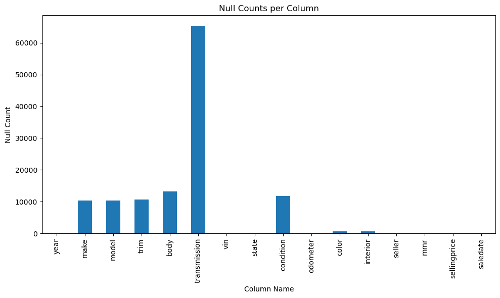

```python
plt.figure(figsize=(10,6))
null_counts.plot(kind='bar')
plt.title('Null Counts per Column')
plt.xlabel('Column Name')
plt.ylabel('Null Count')
plt.xticks(rotation=90)
plt.tight_layout()
plt.show()
```

### ● Resolve null values by appropriate strategy based on the datatype and percentage of null values

```python
null_percentages = (cars_list.isnull().sum()/len(cars_list))*100
```

```python
null_percentages ## Before null removal
```

[output not shown]

```python
cars_list['make'] = cars_list['make'].fillna(cars_list['make'].mode().iloc[0])
```

```python
cars_list['model'] = cars_list['model'].fillna(cars_list['model'].mode().iloc[0])
```

```python
cars_list['trim'] = cars_list['trim'].fillna(cars_list['trim'].mode().iloc[0])
```

```python
cars_list['body'] = cars_list['body'].fillna(cars_list['body'].mode().iloc[0])
```

```python
cars_list['transmission'] = cars_list['transmission'].fillna(cars_list['transmission'].mode().iloc[0])
```

```python
cars_list['vin'] = cars_list['vin'].fillna(cars_list['vin'].mode().iloc[0])
```

```python
cars_list['state'] = cars_list['state'].fillna(cars_list['state'].mode().iloc[0])
```

```python
cars_list['color'] = cars_list['color'].fillna(cars_list['color'].mode().iloc[0])
```

```python
cars_list['interior'] = cars_list['interior'].fillna(cars_list['interior'].mode().iloc[0])
```

```python
cars_list['seller'] = cars_list['seller'].fillna(cars_list['seller'].mode().iloc[0])
```

```python
cars_list['saledate'] = cars_list['saledate'].fillna(cars_list['saledate'].mode().iloc[0])
```

```python
cars_list['condition'] = cars_list['condition'].fillna(cars_list['condition'].mean())
```

```python
cars_list['odometer'] = cars_list['odometer'].fillna(cars_list['odometer'].mean())
```

```python
cars_list['sellingprice'] = cars_list['sellingprice'].fillna(cars_list['sellingprice'].mean())
```

```python
cars_list['mmr'] = cars_list['mmr'].fillna(cars_list['mmr'].mean())
```

```python
null_percentages = (cars_list.isnull().sum()/len(cars_list))*100
```

```python
null_percentages ## After null removal
```

```
year            0.0
make            0.0
model           0.0
trim            0.0
body            0.0
transmission    0.0
vin             0.0
state           0.0
condition       0.0
odometer        0.0
color           0.0
interior        0.0
seller          0.0
mmr             0.0
sellingprice    0.0
saledate        0.0
dtype: float64
```

### ● Count number of duplicate records and delete if any present

```python
Duplicate_count = cars_list.duplicated().sum()
```

```python
Duplicate_count
```

```
np.int64(0)
```

```python
cars_list_duplicate_count = cars_list.duplicated(subset=['vin']).sum()    # Checking Duplicates
```

```python
cars_list_duplicate_count
```

```
np.int64(8540)
```

```python
cars_list = cars_list.drop_duplicates(subset=['vin'],keep='first')        # Deleting Duplicates
```

```python
cars_list_duplicate_count = cars_list.duplicated(subset=['vin']).sum()    # Rechecking Duplicates
```

```python
cars_list_duplicate_count
```

```
np.int64(0)
```

## 2. Data frames Queries

### 2.1 Calculate the average, minimum, and maximum car price?

```python
cars_list['sellingprice'].mean()      # Average Car price
```

```
np.float64(13601.17461898888)
```

```python
cars_list['sellingprice'].min()      # Minimum Car price
```

```
1.0
```

```python
cars_list['sellingprice'].max()      # Maximum Car price
```

```
230000.0
```

### 2.2 List all unique colors of cars?

```python
unique_colors = cars_list['color'].unique()      # Unique Car Colors
```

[output not shown]

```python
Unique_Colors_count = cars_list['color'].value_counts()
print(Unique_Colors_count)                                   # Unique Colors Count List
```

```
color
black        109865
white        105078
silver        82027
gray          81632
blue          50417
red           42899
—             24468
green         11245
gold          11141
beige          9083
burgundy       8818
brown          6620
orange         2036
purple         1534
off-white      1418
yellow         1253
charcoal        473
turquoise       232
pink             42
lime             15
4802              1
Name: count, dtype: int64
```

### 2.3 Find the number of unique car brands and car models?

```python
Unique_Car_Brands_Models = cars_list[['make','model']].drop_duplicates()
print (Unique_Car_Brands_Models)
```

```
                 make                model
0                 Kia              Sorento
2                 BMW             3 Series
3               Volvo                  S60
4                 BMW  6 Series Gran Coupe
5              Nissan               Altima
...               ...                  ...
487115          Lexus               RC 350
529862        Ferrari                  360
539490  Mercedes-Benz            GLA-Class
547702          Acura                  TLX
548169        Ferrari           458 Italia

[1022 rows x 2 columns]
```

### 2.4 Find all car information having selling prices greater than $165000?

```python
Cars_prices_above_165000 = cars_list[cars_list['sellingprice']>165000]
print(Cars_prices_above_165000)
```

```
        year           make       model      trim   body transmission  \
125095  2012    Rolls-Royce       Ghost      Base  Sedan    automatic
344905  2014           Ford      Escape  Titanium    SUV    automatic
446949  2015  Mercedes-Benz     S-Class   S65 AMG  Sedan    automatic
538347  2012    Rolls-Royce       Ghost      Base  sedan    automatic
545523  2013    Rolls-Royce       Ghost      Base  sedan    automatic
548169  2011        Ferrari  458 Italia      Base  coupe    automatic
557570  2012    Rolls-Royce       Ghost       EWB  sedan    automatic

                      vin state  condition  odometer  color interior  \
125095  sca664s58cux50727    fl       45.0   14316.0  black    beige
344905  1fmcu9j98eua23833    mo       43.0   27802.0  green      tan
446949  wddug7kb2fa102347    ca       41.0    5277.0  white    white
538347  sca664s59cux50803    ca       44.0    5215.0  white      tan
545523  sca664s52dux52152    fl       42.0    7852.0  white    beige
```

[output cut: 20 more lines]

### 2.5 Find the top 5 most frequently sold car models?

```python
Top5models = cars_list['model'].value_counts().nlargest(5)

print(Top5models)
```

```
model
Altima    29392
F-150     14145
Fusion    12797
Camry     12419
Escape    11711
Name: count, dtype: int64
```

### 2.6 What is the average selling price of cars by brand (make)?

```python
Average_selling_price = cars_list.groupby('make')['sellingprice'].mean()
print(Average_selling_price)
```

```
make
Acura           14017.268260
Aston Martin    54812.000000
Audi            19915.432782
BMW             21441.895748
Bentley         74367.672414
                    ...
subaru           3710.416667
suzuki           4810.000000
toyota           7339.105263
volkswagen       6145.833333
vw              13672.916667
Name: sellingprice, Length: 96, dtype: float64
```

### 2.7 What is the minimum selling price of cars for each interior?

```python
Minimum_selling_price = cars_list.groupby('interior')['sellingprice'].min()
print(Minimum_selling_price)
```

```
interior
beige         100.0
black           1.0
blue          150.0
brown         200.0
burgundy      175.0
gold          250.0
gray            1.0
green         100.0
off-white     900.0
orange       1200.0
purple        200.0
red           200.0
silver        150.0
tan           100.0
white         350.0
yellow       3100.0
—             150.0
Name: sellingprice, dtype: float64
```

### 2.8 Find highest odometer reading per year from highest to lowest order?

```python
Highest_odometer_reading_yearwise = cars_list.groupby('year')['odometer'].max().sort_values(ascending=False)
print(Highest_odometer_reading_yearwise)
```

```
year
1997    999999.0
1996    999999.0
2014    999999.0
2013    999999.0
1998    999999.0
1999    999999.0
1993    999999.0
2010    999999.0
2009    999999.0
2012    999999.0
2008    999999.0
2007    999999.0
2005    999999.0
2006    999999.0
```

[output cut: 21 more lines]

### 2.9 Create a new column for car age (assuming the current year is 2025)

```python
cars_list['Car_age'] = 2025 - cars_list['year']
print(cars_list[['year','make','model','Car_age']])
```

```
        year    make                model  Car_age
0       2015     Kia              Sorento       10
1       2015     Kia              Sorento       10
2       2014     BMW             3 Series       11
3       2015   Volvo                  S60       10
4       2014     BMW  6 Series Gran Coupe       11
...      ...     ...                  ...      ...
558832  2015     Kia                 K900       10
558833  2012     Ram                 2500       13
558834  2012     BMW                   X5       13
558835  2015  Nissan               Altima       10
558836  2014    Ford                F-150       11

[550297 rows x 4 columns]
```

### 2.10 Find the number of cars having a condition greater than or equal to 48 and odometer greater than 90000?

```python
Cars_condition_odometer = cars_list[(cars_list['condition']>=48) & (cars_list['odometer']>90000)].shape[0]
print(Cars_condition_odometer)
```

```
734
```

### 2.11 Which state consistently has higher car prices for newer cars(year>2013)?

```python
cars_list = pd.read_csv(r'C:\Users\Hp\Desktop\Python Assignment\Dataset-Python-001\Dataset\car_prices.csv')
```

```python
newer_cars = cars_list[cars_list['year']>2013]
```

```python
Newer_cars_avg_price = newer_cars.groupby('state')['sellingprice'].mean().sort_values(ascending=False)
```

```python
print(Newer_cars_avg_price.head(1))
```

```
state
oh    28020.221053
Name: sellingprice, dtype: float64
```

```python
print(cars_list[cars_list['condition']<=cars_list['condition'].quantile(0.2)].groupby('make')['mmr'].mean().sort_values().head(5))
```

```
make
Daewoo        500.000000
ford truck    550.000000
plymouth      583.333333
Geo           585.294118
dodge tk      625.000000
Name: mmr, dtype: float64
```

## 3. Data Visualization and insights

### 3.1 Show the correlation of all the features(columns) having numerical values(e.g. selling price, odometer)

```python
import seaborn as sns
```

```python
numerical_Cols = ['year','condition','odometer','mmr','sellingprice']
corr_matrix = cars_list[numerical_Cols].corr()
```

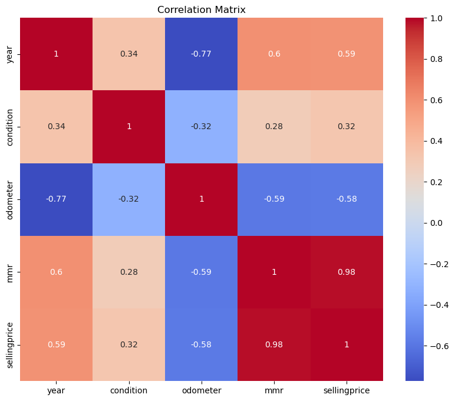

```python
plt.figure(figsize=(10,8))
sns.heatmap(corr_matrix,annot=True,cmap='coolwarm',square=True)
plt.title('Correlation Matrix')
plt.show()
```

### 3.2 Plot a graph to show the average selling price by year and explain the pattern you notice from the graph. Which plot will you use bar or scatter?

```python
import pandas as pd
import matplotlib.pyplot as plt
```

##### A bar chart is perfect for summarizing this relationship between selling price and year as it is clear to compare the difference in avg selling price yearwise. Scatter Chart is more suitable for finding relationship between the two numerical values category. Here, we're comparing categorical values (years) with numerical values (average selling prices). Each bar represents the average selling price for a specific year, making it easy to compare prices across different years.

```python
# Calculating the average selling price by year
avg_price_by_year = cars_list.groupby('year')['sellingprice'].mean().reset_index()
```

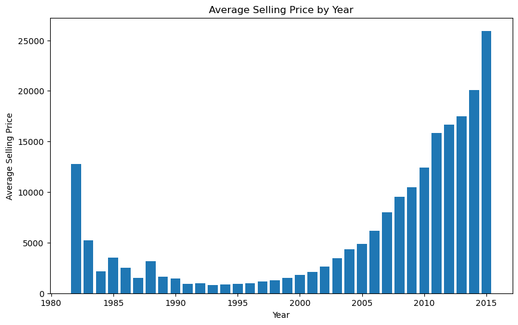

```python
# Plotting the average selling price by year
plt.figure(figsize=(10, 6))
plt.bar(avg_price_by_year['year'], avg_price_by_year['sellingprice'])
plt.xlabel('Year')
plt.ylabel('Average Selling Price')
plt.title('Average Selling Price by Year')
plt.show()
```

##### From the graph pattern , following can be concluded:

A) The average selling price decreased from 1982 to 1995 due to miscellaneous reasons such as market demand variations and increased from 1995 till 2015 which can be due to new car model release or due to new budget release causing newer cars more expensive.

B) The graph can also help identify which years have the highest or lowest average selling prices, providing insights into market trends.

### 3.3 Plot a graph to show average selling price by odometer and explain the trend you notice from the graph.

```python
import pandas as pd
import matplotlib.pyplot as plt
import numpy as np

# odometer reading
cars_list['odometer_reading'] = pd.cut(cars_list['odometer'], bins=np.arange(0, cars_list['odometer'].max()+15000, 15000))

# Calculating the average selling price by odometer reading
avg_price_by_odometer = cars_list.groupby('odometer_reading')['sellingprice'].mean().reset_index()
```

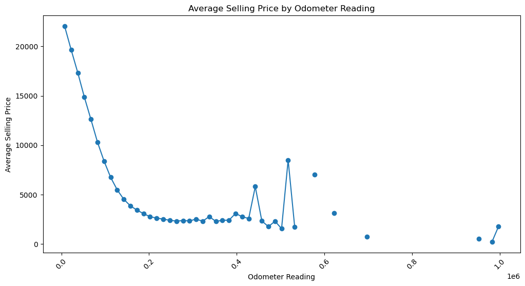

```python
plt.figure(figsize=(12,6))
plt.plot(avg_price_by_odometer['odometer_reading'].apply(lambda x: x.mid), avg_price_by_odometer['sellingprice'], marker='o')
plt.xlabel('Odometer Reading')
plt.ylabel('Average Selling Price')
plt.title('Average Selling Price by Odometer Reading')
plt.xticks(rotation=45)
plt.show()
```

### 3.4 Plot a graph to show the number of cars sold in each state. Find the top three highest car selling states by having a look at the graph?

```python
# Counting the number of cars sold in each state
cars_sold_by_state = cars_list['state'].value_counts().reset_index()
cars_sold_by_state.columns = ['state', 'count']
```

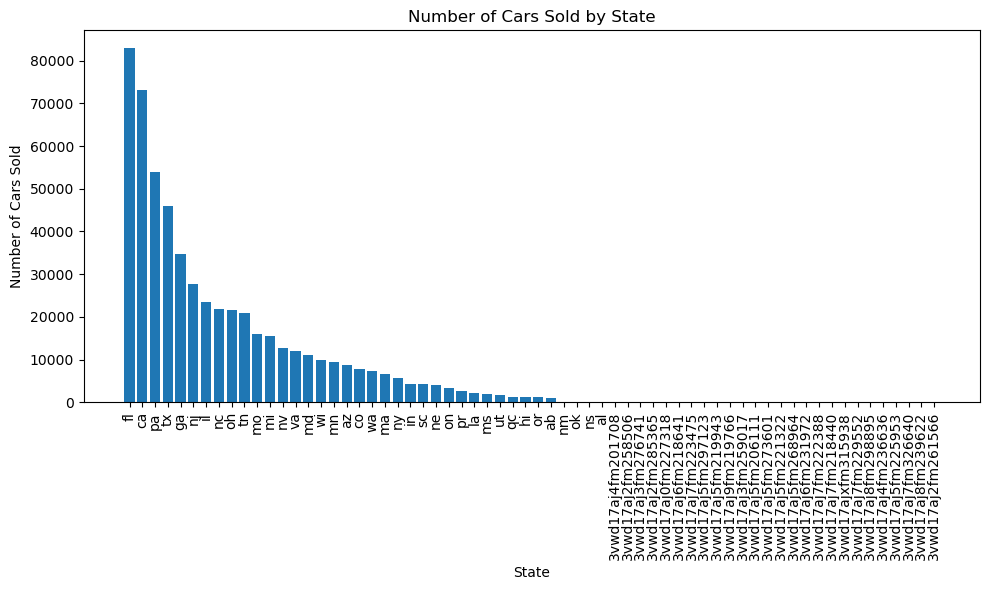

```python
# Plotting the number of cars sold in each state
plt.figure(figsize=(10, 6))
plt.bar(cars_sold_by_state['state'], cars_sold_by_state['count'])
plt.xlabel('State')
plt.ylabel('Number of Cars Sold')
plt.title('Number of Cars Sold by State')
plt.xticks(rotation=90)
plt.tight_layout()
plt.show()
```

##### Result : By Looking in the graph, it is visible that highest top 3 selling cars states are fl,ca & pa having 82945,73148 & 53907 cars respectively.

```python
top_three_states_Cars_Sellers = cars_sold_by_state.nlargest(3, 'count')
print(top_three_states_Cars_Sellers)
```

```
  state  count
0    fl  82945
1    ca  73148
2    pa  53907
```

### 3.5 Plot a bar graph of average selling price by condition score ranges of size 5. Give a summary of the insights

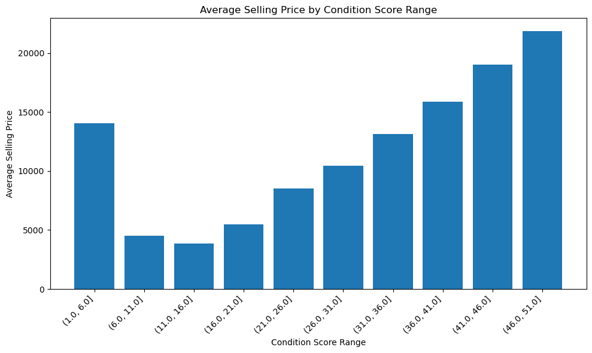

```python
# Creating the condition score ranges of size 5
cars_list['condition_range'] = pd.cut(cars_list['condition'], bins=np.arange(cars_list['condition'].min(), cars_list['condition'].max()+5, 5))

# Calculating the average selling price by condition score range
avg_price_by_condition = cars_list.groupby('condition_range', observed=True)['sellingprice'].mean().reset_index()

# Plotting the average selling price by condition score range
plt.figure(figsize=(10, 6))
plt.bar(avg_price_by_condition['condition_range'].astype(str), avg_price_by_condition['sellingprice'])
plt.xlabel('Condition Score Range')
plt.ylabel('Average Selling Price')
plt.title('Average Selling Price by Condition Score Range')
plt.xticks(rotation=45, ha='right')
plt.tight_layout()
plt.show()
```

### 3.6 Plot a bar graph of no. of cars sold by condition ranges of size 10. Give some insights from the graph.

```python
# Creating the condition score ranges of size 10
cars_list['condition_range'] = pd.cut(cars_list['condition'], bins=np.arange(cars_list['condition'].min(), cars_list['condition'].max()+10, 10))

# Counting the number of cars sold by condition score range
cars_sold_by_condition = cars_list['condition_range'].value_counts().sort_index().reset_index()
cars_sold_by_condition.columns = ['condition_range', 'count']
```

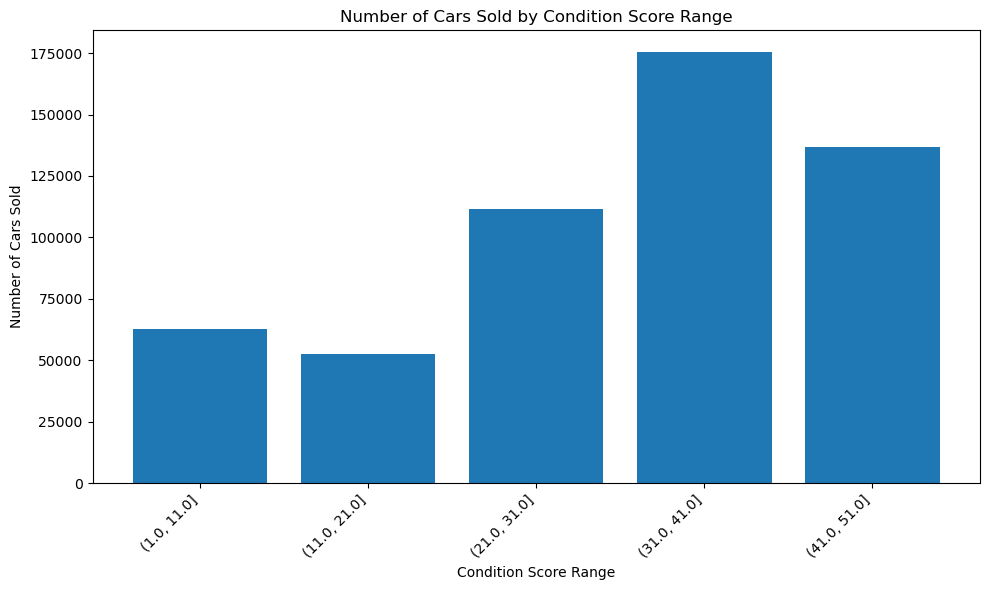

```python
# Plotting the number of cars sold by condition score range
plt.figure(figsize=(10, 6))
plt.bar(cars_sold_by_condition['condition_range'].astype(str), cars_sold_by_condition['count'])
plt.xlabel('Condition Score Range')
plt.ylabel('Number of Cars Sold')
plt.title('Number of Cars Sold by Condition Score Range')
plt.xticks(rotation=45, ha='right')
plt.tight_layout()
plt.show()
```

Here are some potential insights from the graph:

- Most cars sold are in a (31-41) condition range: The graph may show that most cars sold are in this particular condition range, indicating that buyers are more likely to purchase cars that are in a certain specific condition.
- Condition range with the highest demand: The graph identifies that the condition range cars (31-41) has the highest demand, which could inform inventory management and pricing decisions.
- Trend in car sales by condition: The graph shows a drop in car sales by condition, such as a decrease in sales as the condition score worsens from 30 to 10. This could indicate that buyers are more willing to pay for cars that are in better condition.
- Condition ranges with low sales: The graph may also highlight condition ranges with low sales, which could indicate that cars in these conditions are not as desirable or are overpriced.
- Opportunities for businesses: By analyzing the graph, businesses can identify opportunities to focus on cars conditions for improving to certain level range for highest selling price and profit range

### 3.7 Plot a box plot to show the distribution of car selling prices grouped by color. Extract insights and if required, remove outliers and plot the graph again.

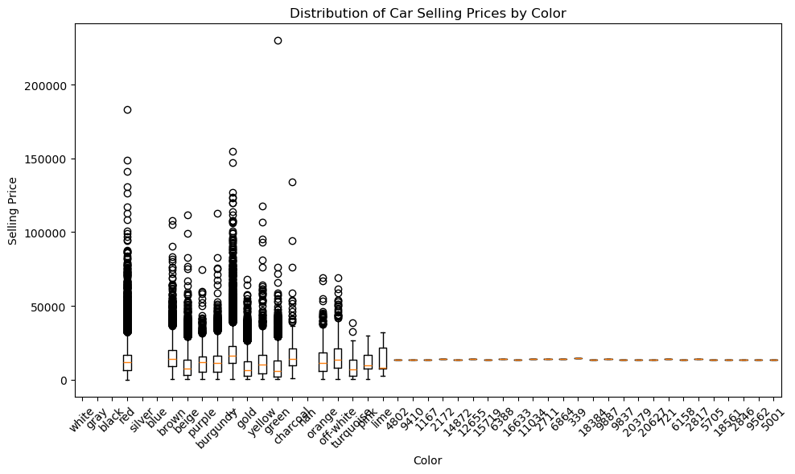

```python
import matplotlib.pyplot as plt

# Plot the distribution of car selling prices grouped by color
plt.figure(figsize=(10, 6))
plt.boxplot([cars_list.loc[cars_list['color'] == color, 'sellingprice'] for color in cars_list['color'].unique()], labels=cars_list['color'].unique())
plt.xlabel('Color')
plt.ylabel('Selling Price')
plt.title('Distribution of Car Selling Prices by Color')
plt.xticks(rotation=45)
plt.tight_layout()
plt.show()
```

Insights: